# U-TAD - PEDS: Práctica 14 - Técnicas de aprendizaje no supervisado

Rafael Enríquez-Herrador (rafael.enriquez@live.u-tad.com)

17/02/2016

## Análisis de aceites de oliva (II)

Analizar los clústers construidos sea con *k-medias* o con *k-medioides*:

- ¿Qué variables son las que más distinguen los clústers? ¿Alguna no lo hace?
- ¿Puedes hacer un pequeño estudio de la calidad del clúster (gráficos de bandera o similar)?
- Estudiar uno de los clústers y mostrar la distribución de las variables en él. Comparar con la distribución de la muestra entera.
- ¿Se correlacionan estos clústers con las variables geográficas?

Cargamos las librerías que utilizaremos:

```r
# install.packages("ggplot2")
library(ggplot2)
# install.packages("devtools")
library(devtools)
install_github("pablo14/clusplus")
```

```
## Installing clusplus
## '/usr/lib/R/bin/R' --no-site-file --no-environ --no-save --no-restore  \
##   CMD INSTALL  \
##   '/tmp/RtmpJ2C8NJ/devtools492c72cdc47c/pablo14-clusplus-99251ea'  \
##   --library='/home/renqher/R/x86_64-pc-linux-gnu-library/3.2'  \
##   --install-tests
```

```r
library(clusplus)
```

Cargamos los datos:

```r
set.seed(1234)

olive <- read.table(file = "../dat/olive.txt", header = T, sep = "\t")
data <- scale(olive[, -c(1, 2, 11)])
```

Generemos 6 clústeres para *k-means* y analizamos el peso de cada variable del *dataset* para cada clúster usando la función *plot_clus_coord* del paquete **pablo14/clusplus**:

```r
fit.km <- kmeans(data, centers = 6, nstart = 25)
aggregate(olive[, 3:10], by=list(cluster=fit.km$cluster), mean)
```

```
##   cluster palmitic palmitoleic  stearic    oleic  linoleic linolenic
## 1       1 1310.525   122.82500 259.6375 7263.688  851.9250  44.97500
## 2       2 1114.194    96.61165 226.3689 7283.165 1176.4078  27.52427
## 3       3 1105.419    69.16279 212.0116 7879.512  629.7558  31.23256
## 4       4 1040.487    63.35897 268.9744 7746.103  715.1795  45.12821
## 5       5 1398.270   184.80392 209.6618 6908.250 1166.8971  34.61275
## 6       6 1067.667   103.83333 255.5000 7700.667  857.3333   5.00000
##   arachidic eicosenoic
## 1 69.937500  29.462500
## 2 74.087379   1.902913
## 3 51.813953   3.069767
## 4 71.641026  37.076923
## 5 59.637255  24.151961
## 6  9.833333   2.050000
```

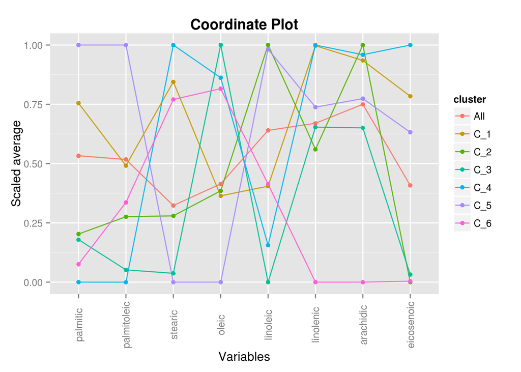

```r
plot_clus_coord(fit.km, data)
```

Veamos como se corresponden los clústeres con las regiones geográficas:

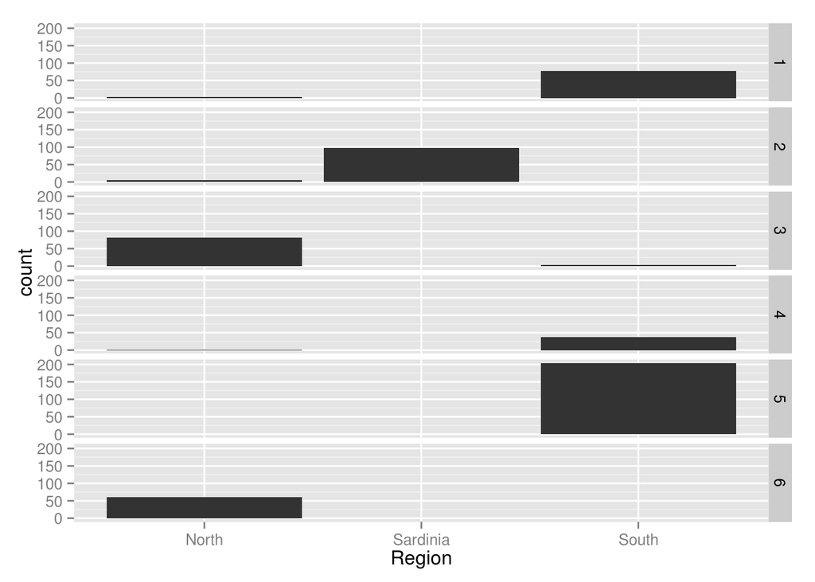

```r
df <- olive
df$cluster <- fit.km$cluster
ggplot(df, aes(x = Region)) + geom_bar() + facet_grid(cluster ~ .)
```

```r
table(fit.km$cluster, olive$Region)
```

```
##
##     North Sardinia South
##   1     3        0    77
##   2     5       98     0
##   3    82        0     4
##   4     1        0    38
##   5     0        0   204
##   6    60        0     0
```

Y lo mismo con las áreas geográficas:

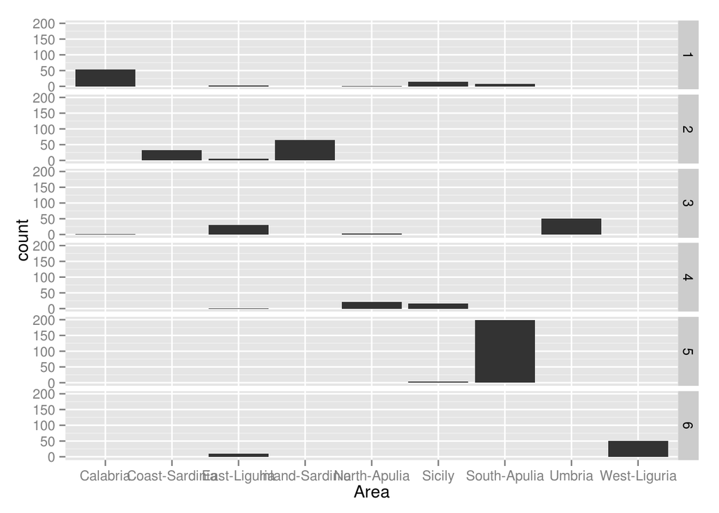

```r
ggplot(df, aes(x = Area)) + geom_bar() + facet_grid(cluster ~ .)
```

```r
table(fit.km$cluster, olive$Area)
```

```
##
##     Calabria Coast-Sardinia East-Liguria Inland-Sardinia North-Apulia
##   1       54              0            3               0            1
##   2        0             33            5              65            0
##   3        1              0           31               0            3
##   4        0              0            1               0           21
##   5        1              0            0               0            0
##   6        0              0           10               0            0
##
##     Sicily South-Apulia Umbria West-Liguria
##   1     15            7      0            0
##   2      0            0      0            0
##   3      0            0     51            0
##   4     17            0      0            0
##   5      4          199      0            0
##   6      0            0      0           50
```